# Exponential_Smoothing_us_retail

### Forecasting - SES and Exponential Smoothing

This notebook demonstrates how to forecast time series using Simple Exponential Smoothing (SES) and the more general Exponential Smoothing methods. This notebook builds off the concepts introduced last week which forecasted using the MEAN and Naive methods. These two fundamental approaches weight historical data. The MEAN method assumes all data are equally important, while the Naive method considers the most recent observation as the only data point that matters. The SES method **automates** weighting the historical data for you. The SES method however can be limiting because it is only appropriate there is **no trend** and **no seasonality** in the time series. The more general Exponential Smoothing methods overcome these limitations.

This notebook uses the US Retail Employment data set introduced last week.

## Import Modules

```python
import numpy as np
import pandas as pd
import matplotlib.pyplot as plt

import seaborn as sns
```

```python
import statsmodels.api as sm
```

## Read data

Use the monthly US Retail Employment data set introduced last week.

```python
us_retail_df = pd.read_csv('../week_10/us_retail_employment.csv')
```

```python
us_retail_df.info()
```

```
<class 'pandas.core.frame.DataFrame'>
RangeIndex: 357 entries, 0 to 356
Data columns (total 4 columns):
 #   Column    Non-Null Count  Dtype
---  ------    --------------  -----
 0   Year      357 non-null    int64
 1   Month     357 non-null    int64
 2   Day       357 non-null    int64
 3   Employed  357 non-null    float64
dtypes: float64(1), int64(3)
memory usage: 11.3 KB
```

```python
us_retail_df.head()
```

|  | Year | Month | Day | Employed |
| --- | --- | --- | --- | --- |
| 0 | 1990 | 1 | 1 | 13255.8 |
| 1 | 1990 | 2 | 1 | 12966.3 |
| 2 | 1990 | 3 | 1 | 12938.2 |
| 3 | 1990 | 4 | 1 | 13012.3 |
| 4 | 1990 | 5 | 1 | 13108.3 |

## Prepare data

We need to create the datetime object column and then separate the `Employed` column into its own Series. Those actions were discussed in more detail last week.

```python
us_retail_df['date_dt'] = pd.to_datetime( us_retail_df.loc[:, ['Year', 'Month', 'Day']] )
```

```python
us_retail_df.info()
```

```
<class 'pandas.core.frame.DataFrame'>
RangeIndex: 357 entries, 0 to 356
Data columns (total 5 columns):
 #   Column    Non-Null Count  Dtype
---  ------    --------------  -----
 0   Year      357 non-null    int64
 1   Month     357 non-null    int64
 2   Day       357 non-null    int64
 3   Employed  357 non-null    float64
 4   date_dt   357 non-null    datetime64[ns]
dtypes: datetime64[ns](1), float64(1), int64(3)
memory usage: 14.1 KB
```

```python
us_retail_df.head()
```

|  | Year | Month | Day | Employed | date_dt |
| --- | --- | --- | --- | --- | --- |
| 0 | 1990 | 1 | 1 | 13255.8 | 1990-01-01 |
| 1 | 1990 | 2 | 1 | 12966.3 | 1990-02-01 |
| 2 | 1990 | 3 | 1 | 12938.2 | 1990-03-01 |
| 3 | 1990 | 4 | 1 | 13012.3 | 1990-04-01 |
| 4 | 1990 | 5 | 1 | 13108.3 | 1990-05-01 |

Visualize the `Employed` column vs the `date_dt` column using Seaborn.

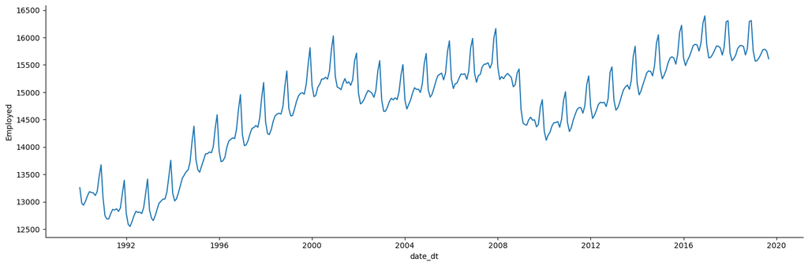

```python
sns.relplot(data = us_retail_df, x='date_dt', y='Employed', kind='line', aspect=3)

plt.show()
```

Extract the Series.

```python
retail_series = us_retail_df.Employed.copy()
```

```python
retail_series
```

```
0      13255.8
1      12966.3
2      12938.2
3      13012.3
4      13108.3
        ...
352    15691.6
353    15775.5
354    15785.9
355    15749.5
356    15611.3
Name: Employed, Length: 357, dtype: float64
```

```python
retail_series.index
```

```
RangeIndex(start=0, stop=357, step=1)
```

Set the index to a DateTimeIndex to enable using Time Series methods.

```python
retail_series.index = us_retail_df.date_dt
```

```python
retail_series
```

```
date_dt
1990-01-01    13255.8
1990-02-01    12966.3
1990-03-01    12938.2
1990-04-01    13012.3
1990-05-01    13108.3
               ...
2019-05-01    15691.6
2019-06-01    15775.5
2019-07-01    15785.9
2019-08-01    15749.5
2019-09-01    15611.3
Name: Employed, Length: 357, dtype: float64
```

```python
retail_series.index
```

```
DatetimeIndex(['1990-01-01', '1990-02-01', '1990-03-01', '1990-04-01',
               '1990-05-01', '1990-06-01', '1990-07-01', '1990-08-01',
               '1990-09-01', '1990-10-01',
               ...
               '2018-12-01', '2019-01-01', '2019-02-01', '2019-03-01',
               '2019-04-01', '2019-05-01', '2019-06-01', '2019-07-01',
               '2019-08-01', '2019-09-01'],
              dtype='datetime64[ns]', name='date_dt', length=357, freq=None)
```

We can **RESAMPLE** the data to force a regular **sampling frequency** to support traditional/classic time series methods.

```python
ready_series = retail_series.copy().resample('MS').mean()
```

```python
ready_series
```

```
date_dt
1990-01-01    13255.8
1990-02-01    12966.3
1990-03-01    12938.2
1990-04-01    13012.3
1990-05-01    13108.3
               ...
2019-05-01    15691.6
2019-06-01    15775.5
2019-07-01    15785.9
2019-08-01    15749.5
2019-09-01    15611.3
Freq: MS, Name: Employed, Length: 357, dtype: float64
```

Visualize the Series plot.

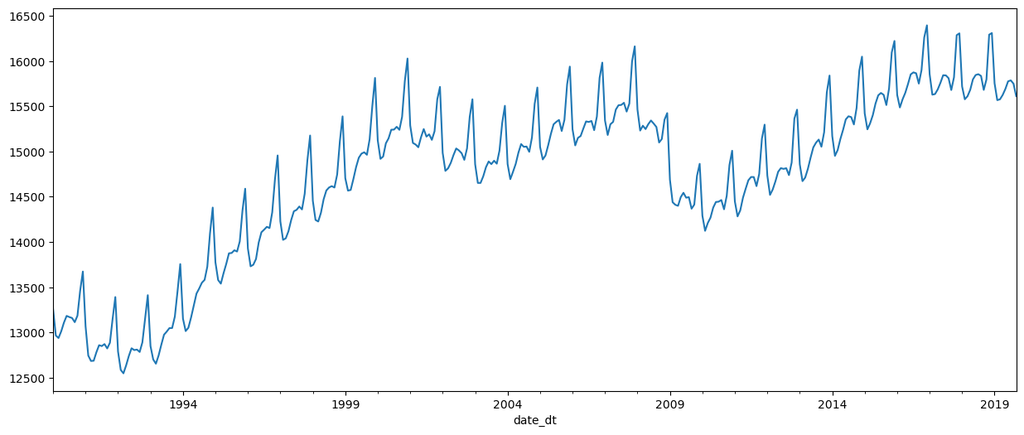

```python
ready_series.plot( figsize=(15, 6) )

plt.show()
```

## Split data

The goal of time series forecasters is to **forecast** the future...so we should **NOT** randomly split time series data. Instead, we should force the hold-out test set to be in the future. Last week, we **split** the data such that the TRAINING SET consisted of all observations BEFORE 2017. The hold out TEST SET is therefore all observations from the start of 2017 onward.

We can split the data using the `DateTimeIndex`.

```python
ready_series.loc[ ready_series.index < '2017-01-01' ]
```

```
date_dt
1990-01-01    13255.8
1990-02-01    12966.3
1990-03-01    12938.2
1990-04-01    13012.3
1990-05-01    13108.3
               ...
2016-08-01    15864.6
2016-09-01    15750.3
2016-10-01    15899.5
2016-11-01    16260.2
2016-12-01    16394.3
Freq: MS, Name: Employed, Length: 324, dtype: float64
```

Create the training set.

```python
train_series = ready_series.loc[ ready_series.index < '2017-01-01' ].copy()
```

Create the hold-out "future" test set.

```python
test_series = ready_series.loc[ ready_series.index >= '2017-01-01' ].copy()
```

Visualize the TRAINING set and the HOLD-OUT future test set.

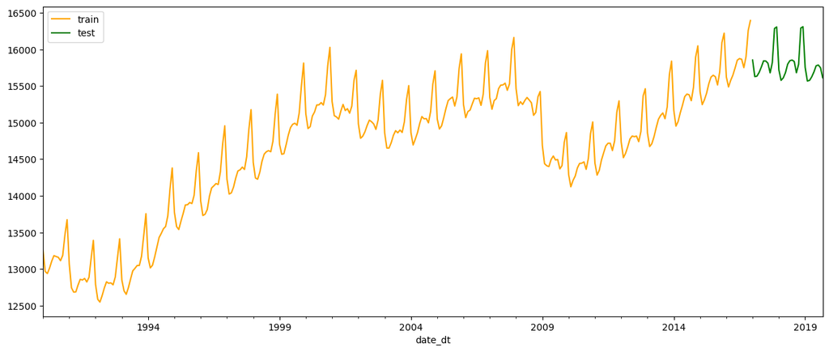

```python
fig, ax = plt.subplots(figsize=(15, 6))

train_series.plot( ax = ax, label = 'train', color='orange' )

test_series.plot( ax = ax, label = 'test', color = 'green' )

ax.legend()

plt.show()
```

## Simple Forecasting

As a quick review, the two simplest forecasting methods are:

- Average all historical measurements - all future forecasts equal the AVERAGE
- Use the most recent (last) observation as the forecast -> Naive method

The average or *MEAN* method is easy to calculate...

```python
train_series.mean()
```

```
14623.75277777778
```

The most recent or last observation is the Naive forecaster:

```python
train_series.iloc[ -1 ]
```

```
16394.3
```

Make these simple forecasts on the hold out test set.

Let's compile everything into a Pandas DataFrame.

```python
my_forecasts = pd.DataFrame({'observed': test_series.values.copy() },
                            index=test_series.index)
```

```python
my_forecasts.head()
```

| date_dt | observed |
| --- | --- |
| 2017-01-01 | 15854.4 |
| 2017-02-01 | 15627.9 |
| 2017-03-01 | 15635.0 |
| 2017-04-01 | 15686.6 |
| 2017-05-01 | 15759.5 |

Add in the MEAN and Naive forecasts.

```python
my_forecasts['AVERAGE'] = train_series.mean()
```

```python
my_forecasts['Naive'] = train_series.iloc[-1].copy()
```

```python
my_forecasts.head()
```

| date_dt | observed | AVERAGE | Naive |
| --- | --- | --- | --- |
| 2017-01-01 | 15854.4 | 14623.752778 | 16394.3 |
| 2017-02-01 | 15627.9 | 14623.752778 | 16394.3 |
| 2017-03-01 | 15635.0 | 14623.752778 | 16394.3 |
| 2017-04-01 | 15686.6 | 14623.752778 | 16394.3 |
| 2017-05-01 | 15759.5 | 14623.752778 | 16394.3 |

Let's use Pandas plotting and matplotlib plotting to include the Training set and the forecasts and the test set in a single plot.

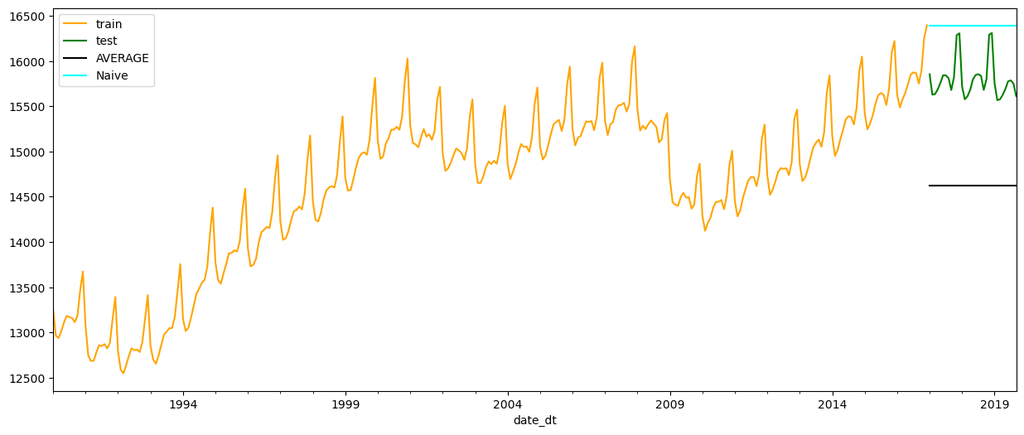

```python
fig, ax = plt.subplots( figsize=(15, 6) )

train_series.plot(ax=ax, label='train', color='orange' )

test_series.plot(ax=ax, label='test', color='green' )

my_forecasts.AVERAGE.plot( ax=ax, label='AVERAGE', color='black' )

my_forecasts.Naive.plot( ax=ax, label='Naive', color='cyan' )

ax.legend()

plt.show()
```

The simple MEAN and Naive methods are the building blocks for all other forecasting strategies. Last week, we also discussed the SEASONAL NAIVE method and an approach that combines the STL decomposition with a simple Naive forecastor. Those two methods will not be repeated here, but please recall that the SEASONAL NAIVE method was the **BEST** out of the 4 models on the hold out test set.

## Time Series Forecasting Methods

All "more advanced" forecasters build on the previously illustrated methods. The "more advanced" approaches try to "blend" aspects of the historical average, the most recent measurement, and seasonal behavior.

The average method treats ALL historical measurements as EQUALLY important. Whereas the Naive method treats only the most recent measurement as being important. Seasonal Naive treats the last year's seasonal measurement as the most important.

### Simple Exponential Smoothing (SES)

SES "blends" the Average and Naive methods together to find the "optimal" weight to apply to the historical data.

```python
from statsmodels.tsa.api import SimpleExpSmoothing
```

```python
train_ses_model = SimpleExpSmoothing( train_series, initialization_method='estimated' )
```

```python
train_ses_model_fit = train_ses_model.fit(optimized=True)
```

```python
print( train_ses_model_fit.summary() )
```

```
                       SimpleExpSmoothing Model Results
==============================================================================
Dep. Variable:               Employed   No. Observations:                  324
Model:             SimpleExpSmoothing   SSE                       18549628.593
Optimized:                       True   AIC                           3553.490
Trend:                           None   BIC                           3561.052
Seasonal:                        None   AICC                          3553.616
Seasonal Periods:                None   Date:                 Tue, 14 Mar 2023
Box-Cox:                        False   Time:                         19:51:20
Box-Cox Coeff.:                  None
==============================================================================
                       coeff                 code              optimized
------------------------------------------------------------------------------
smoothing_level            0.9950000                alpha                 True
initial_level              13040.900                  l.0                 True
------------------------------------------------------------------------------
```

Let's forecast with the fitted SES model. The `.forecast()` method requires that we specify the "number of forecast" **steps** or **number of horizons**.

We are forecasting 12 months + 12 months + 9 months or a total of 33 months into the future.

Which equals the size of the test set.

```python
test_series.size
```

```
33
```

But, let's begin by specifying a forecast of 1 step or 1 horizon **into the future** (relative to the END of the TRAINING SET).

```python
train_ses_model_fit.forecast( 1 )
```

```
2017-01-01    16393.620464
Freq: MS, dtype: float64
```

```python
train_ses_model_fit.forecast( 2 )
```

```
2017-01-01    16393.620464
2017-02-01    16393.620464
Freq: MS, dtype: float64
```

Forecasting 1 year into the future corresponds to 12 horizons. Please note if we were working with Quarterly data, one year into the future corresponds to 4 horizons. The interval of time spanned by a single horizon depends on the sampling frequency of the time series.

```python
train_ses_model_fit.forecast(12)
```

```
2017-01-01    16393.620464
2017-02-01    16393.620464
2017-03-01    16393.620464
2017-04-01    16393.620464
2017-05-01    16393.620464
2017-06-01    16393.620464
2017-07-01    16393.620464
2017-08-01    16393.620464
2017-09-01    16393.620464
2017-10-01    16393.620464
2017-11-01    16393.620464
2017-12-01    16393.620464
Freq: MS, dtype: float64
```

Forecasting the entire hold out TEST SET corresponds to forecasting as many horizons as elements in the Series.

```python
ses_forecast = train_ses_model_fit.forecast( test_series.size )
```

```python
ses_forecast
```

```
2017-01-01    16393.620464
2017-02-01    16393.620464
2017-03-01    16393.620464
2017-04-01    16393.620464
2017-05-01    16393.620464
2017-06-01    16393.620464
2017-07-01    16393.620464
2017-08-01    16393.620464
2017-09-01    16393.620464
2017-10-01    16393.620464
2017-11-01    16393.620464
2017-12-01    16393.620464
2018-01-01    16393.620464
2018-02-01    16393.620464
2018-03-01    16393.620464
2018-04-01    16393.620464
2018-05-01    16393.620464
2018-06-01    16393.620464
2018-07-01    16393.620464
2018-08-01    16393.620464
2018-09-01    16393.620464
2018-10-01    16393.620464
2018-11-01    16393.620464
2018-12-01    16393.620464
2019-01-01    16393.620464
2019-02-01    16393.620464
2019-03-01    16393.620464
2019-04-01    16393.620464
2019-05-01    16393.620464
2019-06-01    16393.620464
2019-07-01    16393.620464
2019-08-01    16393.620464
2019-09-01    16393.620464
Freq: MS, dtype: float64
```

Visualize the predictions on the TRAINING set and the *forecasts* on the TEST set in one figure. We will only focus on the SES model and not the previous simplier forecastors.

The training set predictions are called the **FITS** or **fitted values** just like "regular" regression models. The "fits" can be accessed by the `.fittedvalues` attribute.

```python
train_ses_model_fit.fittedvalues
```

```
date_dt
1990-01-01    13040.900000
1990-02-01    13254.725500
1990-03-01    12967.742127
1990-04-01    12938.347711
1990-05-01    13011.930239
                  ...
2016-08-01    15874.284335
2016-09-01    15864.648422
2016-10-01    15750.871742
2016-11-01    15898.756859
2016-12-01    16258.392784
Freq: MS, Length: 324, dtype: float64
```

Visualize all training set predictions and future (hold out TEST SET) forecasts. The SES model has **turned into** the Naive forecastor! The training set "fitted values" look like a "shadow" or shifted version of the training set. That is due to the Naive method "forecasting tomorrow based on today".

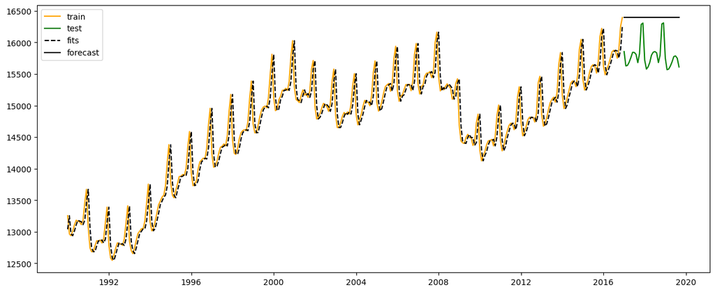

```python
fig, ax = plt.subplots( figsize=(15, 6) )

ax.plot( train_series, color='orange', label='train' )

ax.plot( test_series, color = 'green', label ='test' )

ax.plot( train_ses_model_fit.fittedvalues, color='black', linestyle='--', label='fits' )

ax.plot( ses_forecast, color='black', label='forecast' )

ax.legend()

plt.show()
```

However, why would SES convert to the Naive forecastor? The SES is best suited when there is **NO** trend **AND** there is **NO** seasonal pattern! This data set clearly has **both**! Thus, the SES method is not well suited to this application, but it is still useful to fit because it will serve as a benchmark for more advanced methods.

### Exponential Smoothing

We can include **trends** and **seasonal patterns** to improve the model. These more general approaches are referred to as **Exponential Smoothing** models. However, Exponential Smoothing models are given **specific** names based on the types of components/patterns they can handle.

The **Holt** method is SES with TRENDS.

The **Holt-Winters** method is SES with TRENDS and SEASONS.

```python
from statsmodels.tsa.api import ExponentialSmoothing
```

We know this data has a Seasonal component and a Trend. So let's jump straight to the Holt-Winters method instead of first examining the Holt Method. You **must** specify the `seasonal_periods` argument when initializing the `ExponentialSmoothing()` function. Monthly data has 12 seasonal periods in a year. Quarterly data has 4 seasonal periods in a year. The TREND is included by setting `trend='add'` and the SEASON component is included by setting `seasonal='add'`. If we only specified `trend='add'` and did **not** set `seasonal` the we would fit a Holt model instead of Holt-Winters.

```python
train_hw_model = ExponentialSmoothing(train_series, seasonal_periods=12,
                                      trend='add', seasonal='add',
                                      initialization_method='estimated')
```

Apply the `.fit()` method to fit the model.

```python
train_hw_model_fit = train_hw_model.fit()
```

The Holt-Winters model has many more coefficients compared to the SES model.

```python
print( train_hw_model_fit.summary() )
```

```
                       ExponentialSmoothing Model Results
================================================================================
Dep. Variable:                 Employed   No. Observations:                  324
Model:             ExponentialSmoothing   SSE                         475082.726
Optimized:                         True   AIC                           2394.122
Trend:                         Additive   BIC                           2454.614
Seasonal:                      Additive   AICC                          2396.365
Seasonal Periods:                    12   Date:                 Tue, 14 Mar 2023
Box-Cox:                          False   Time:                         20:07:29
Box-Cox Coeff.:                    None
=================================================================================
                          coeff                 code              optimized
---------------------------------------------------------------------------------
smoothing_level               0.8610083                alpha                 True
smoothing_trend               0.2298619                 beta                 True
smoothing_seasonal            0.1387599                gamma                 True
initial_level                 13298.635                  l.0                 True
initial_trend                -23.053011                  b.0                 True
initial_seasons.0            -19.918605                  s.0                 True
initial_seasons.1            -223.49046                  s.1                 True
initial_seasons.2            -249.58532                  s.2                 True
initial_seasons.3            -190.50811                  s.3                 True
initial_seasons.4            -96.416888                  s.4                 True
initial_seasons.5            -23.970649                  s.5                 True
initial_seasons.6            -42.811276                  s.6                 True
initial_seasons.7            -38.422891                  s.7                 True
initial_seasons.8            -52.343931                  s.8                 True
initial_seasons.9             75.343044                  s.9                 True
initial_seasons.10            368.50202                 s.10                 True
initial_seasons.11            583.39408                 s.11                 True
---------------------------------------------------------------------------------
```

Forecast the behavior to examine what was happening.

```python
hw_forecast = train_hw_model_fit.forecast( test_series.size )
```

```python
hw_forecast
```

```
2017-01-01    15773.224401
2017-02-01    15576.272700
2017-03-01    15620.657010
2017-04-01    15677.847842
2017-05-01    15757.909488
2017-06-01    15826.309533
2017-07-01    15822.270685
2017-08-01    15805.648983
2017-09-01    15708.070361
2017-10-01    15862.179665
2017-11-01    16245.406041
2017-12-01    16386.766847
2018-01-01    15764.431568
2018-02-01    15567.479868
2018-03-01    15611.864178
2018-04-01    15669.055009
2018-05-01    15749.116655
2018-06-01    15817.516700
2018-07-01    15813.477853
2018-08-01    15796.856150
2018-09-01    15699.277529
2018-10-01    15853.386832
2018-11-01    16236.613209
2018-12-01    16377.974014
2019-01-01    15755.638736
2019-02-01    15558.687035
2019-03-01    15603.071345
2019-04-01    15660.262176
2019-05-01    15740.323822
2019-06-01    15808.723868
2019-07-01    15804.685020
2019-08-01    15788.063317
2019-09-01    15690.484696
Freq: MS, dtype: float64
```

Visualize the training set "fitted values" and the hold out TEST SET forecasts from the Holt-Winters model. As shown below, the Holt-Winters model captures the variation **very** well! The hold out TEST SET is predicted very well. This is because Holt-Winters includes features that explicitly capture the seasonal variation.

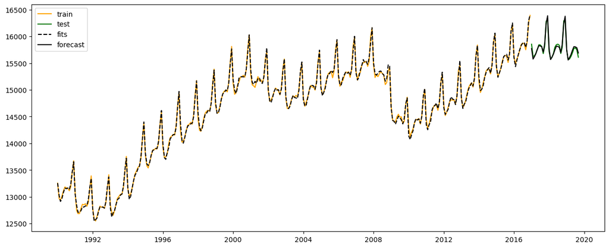

```python
fig, ax = plt.subplots( figsize=(15, 6) )

ax.plot( train_series, color='orange', label='train' )

ax.plot( test_series, color = 'green', label ='test' )

ax.plot( train_hw_model_fit.fittedvalues, color='black', linestyle='--', label='fits' )

ax.plot( hw_forecast, color='black', label='forecast' )

ax.legend()

plt.show()
```

### Model Selection

#### Hold Out Test Set

We can see from the previous figures that the Holt-Winters method is the **BEST** model. The hold out TEST SET forecasts are **very close** to the observations. However, we can quantify the performance using a **performance metric** as discussed last week. For example, we can calculate the hold-out TEST SET RMSE and identify the BEST model as the model with the LOWEST hold out TEST SET RMSE.

The MEAN or AVERAGE method's hold out TEST SET RMSE is:

```python
np.sqrt( ( ( my_forecasts.observed - my_forecasts.AVERAGE )**2 ).mean() )
```

```
1190.6051791210214
```

The Naive method's hold out TEST SET RMSE is:

```python
np.sqrt( ( ( my_forecasts.observed - my_forecasts.Naive )**2 ).mean() )
```

```
632.3527036537291
```

The SES method's hold out TEST SET RMSE is essentially the same value as the Naive method. That is because the SES model essentially turned into the Naive method.

```python
np.sqrt( ( ( test_series - ses_forecast )**2 ).mean() )
```

```
631.7102460279998
```

The Holt-Winters method's hold out TEST SET RMSE is the smallest of these 4 models. As a reminder, last week the Seasonal Naive method had a hold-out TEST SET RMSE of roughly 82. Thus, the Holt-Winters method is even better than the Seasonal Naive method from last week! The Holt-Winters method is capable of capturing patterns that we saw with manually accounting for the Seasonal patterns!

```python
np.sqrt( ( ( test_series - hw_forecast )**2 ).mean() )
```

```
40.61716823186939
```

#### AIC/BIC

The `statsmodels` objects `.summary()` methods displayed information **very similar** to the information associated with Linear Models. The Exponential Smoothing forecasting family uses a **Gaussian Likelihood** just like Linear Models. Many forecasting methods have the **exact same** assumptions as Linear Models!

AIC and BIC require a Likelihood, and the Exponential Smoothing forecasting family includes a Likelihood. Thus, AIC and BIC can be calculated for SES and Exponential Smoothing forecastors! This provides another way to select the BEST model **without** having to split the data into training and test sets! The `.aic` and `.bic` attributes from the `statsmodels` objects can be used to extract the AIC and BIC for the models.

```python
ic_results = pd.DataFrame({'model': ['SES', 'Holt-Winters'],
                           'AIC': [train_ses_model_fit.aic, train_hw_model_fit.aic],
                           'BIC': [train_ses_model_fit.bic, train_hw_model_fit.bic]})
```

Lower values of AIC/BIC are considered better. Thus, even though Holt-Winters has more unknown parameters to estimate compared to SES, the added complexity is worth it according AIC and BIC. Both AIC and BIC are therefore consistent with the hold-out TEST SET model selection.

```python
ic_results
```

|  | model | AIC | BIC |
| --- | --- | --- | --- |
| 0 | SES | 3553.490246 | 3561.051733 |
| 1 | Holt-Winters | 2394.122231 | 2454.614127 |

```python
ic_results['AICc'] = [train_ses_model_fit.aicc, train_hw_model_fit.aicc]
```

It does not matter for this example though. The Holt-Winters method is clearly better than the SES model in this application.

```python
ic_results
```

|  | model | AIC | BIC | AICc |
| --- | --- | --- | --- | --- |
| 0 | SES | 3553.490246 | 3561.051733 | 3553.615638 |
| 1 | Holt-Winters | 2394.122231 | 2454.614127 | 2396.364854 |

## Prediction Uncertainty

Another consequence of the fact that the model involves a LIKELIHOOD is that the model can include **uncertainty** in the predictions. The uncertainty is calculated just like Linear Models because the Likelihood is a Gaussian likelihood! Meaning, we could view the **CONFIDENCE INTERVAL** and the **PREDICTION INTERVAL**. The confidence interval is the uncertainty on the average output or trend, while the prediction interval is the uncertainty of a single measurement.

Time series forecasting is not interested in confidence intervals. We only show the **PREDICTION INTERVALS** for future forecasts in the time series methods! This is because we can only observe the future once. Think back to the 2016 US Presidential election. It does not matter if someone was confident that on average Hillary Clinton would win. The election happened once and only once. The uncertainty in a **single observation** is what really matters!

Accessing the prediction interval for the SES and Exponential Smoothing (like Holt-Winters) in `statsmodels` is rather odd...

Unfortunately we need to generate simulated values and then summarize them.

Let's generate 2000 possible future "paths". Behind the scenes 2000 **replications** or **repetitions** of possible futures are randomly generated. This is accomplished via the `.simulate()` method.

```python
hw_sims = train_hw_model_fit.simulate( test_series.size, repetitions=2000, error='add' )
```

The result is a DataFrame.

```python
type( hw_sims )
```

```
pandas.core.frame.DataFrame
```

The number of columns corresponds to the randomly generated or possible futures.

```python
hw_sims.shape
```

```
(33, 2000)
```

```python
hw_sims.head()
```

|  | 0 | 1 | 2 | 3 | 4 | 5 | 6 | 7 | 8 | 9 | ... | 1990 | 1991 | 1992 | 1993 | 1994 | 1995 | 1996 | 1997 | 1998 | 1999 |
| --- | --- | --- | --- | --- | --- | --- | --- | --- | --- | --- | --- | --- | --- | --- | --- | --- | --- | --- | --- | --- | --- |
| 2017-01-01 | 15795.868436 | 15751.268692 | 15730.003569 | 15763.463333 | 15717.054465 | 15761.421084 | 15779.631095 | 15766.719667 | 15750.660238 | 15785.358437 | ... | 15779.570988 | 15795.835240 | 15695.008344 | 15773.249780 | 15779.403830 | 15837.248912 | 15763.777784 | 15764.515553 | 15842.952971 | 15763.228619 |
| 2017-02-01 | 15582.325545 | 15474.368213 | 15454.488283 | 15583.941885 | 15526.631210 | 15594.156225 | 15580.637517 | 15503.328119 | 15542.800983 | 15588.182568 | ... | 15582.642135 | 15625.988578 | 15490.644404 | 15597.496471 | 15610.837072 | 15621.540040 | 15517.319140 | 15593.855163 | 15739.215754 | 15511.145567 |
| 2017-03-01 | 15604.786320 | 15526.147305 | 15531.116417 | 15540.792595 | 15606.372741 | 15647.935521 | 15639.076699 | 15507.229962 | 15604.714191 | 15674.535280 | ... | 15618.510667 | 15652.273415 | 15511.517546 | 15605.230126 | 15644.804989 | 15667.309968 | 15518.610373 | 15657.090601 | 15862.883859 | 15558.025978 |
| 2017-04-01 | 15720.114433 | 15634.770242 | 15607.866663 | 15592.433520 | 15690.057577 | 15746.493579 | 15627.277042 | 15566.219062 | 15694.030210 | 15702.717873 | ... | 15707.773219 | 15764.560012 | 15540.201484 | 15644.525014 | 15700.506535 | 15727.010748 | 15532.231502 | 15705.167615 | 15924.085926 | 15598.871395 |
| 2017-05-01 | 15815.528536 | 15747.980583 | 15658.105038 | 15674.349135 | 15768.021705 | 15862.241410 | 15700.206285 | 15584.711183 | 15816.952628 | 15762.184587 | ... | 15747.050316 | 15885.822375 | 15618.525230 | 15655.171150 | 15758.078461 | 15802.378883 | 15646.588522 | 15799.794002 | 16057.936050 | 15610.016238 |

5 rows × 2000 columns

We can plot ALL possible futures...but the figure is really difficult to examine...The only obvious point from the figure below is that uncertainty **increases** over time. The model because **more uncertain** the futhur the forecast stretches into the future.

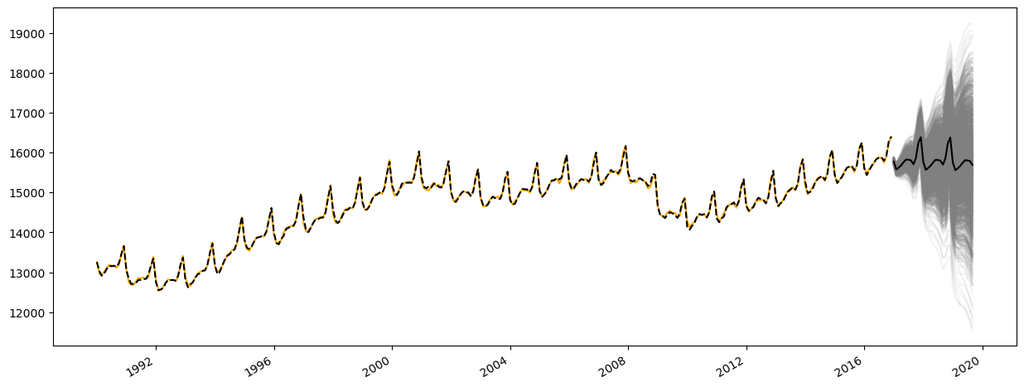

```python
fig, ax = plt.subplots( figsize=(15, 6) )

ax.plot( train_series, color='orange', label='train' )

ax.plot( test_series, color = 'green', label ='test' )

ax.plot( train_hw_model_fit.fittedvalues, color='black', linestyle='--', label='fits' )

hw_sims.plot(ax=ax, color='grey', alpha=0.1, legend=False)

ax.plot( hw_forecast, color='black', label='forecast' )

plt.show()
```

Let's summarize the possible futures by calculating the **AVERAGE**. The average corresponds to the forecast we visualized previously because Linear Models assume the regression model directly predicts the AVERAGE OUTPUT. The random futures are generated **around** this average!

```python
hw_sims.mean(axis=1)
```

```
2017-01-01    15773.121964
2017-02-01    15576.470701
2017-03-01    15621.814079
2017-04-01    15678.919482
2017-05-01    15757.548399
2017-06-01    15826.477197
2017-07-01    15822.800713
2017-08-01    15805.841247
2017-09-01    15708.482060
2017-10-01    15863.420368
2017-11-01    16246.185821
2017-12-01    16385.770338
2018-01-01    15764.254741
2018-02-01    15566.028025
2018-03-01    15610.081334
2018-04-01    15667.690812
2018-05-01    15748.586641
2018-06-01    15815.380343
2018-07-01    15811.158918
2018-08-01    15793.020046
2018-09-01    15695.222350
2018-10-01    15847.848533
2018-11-01    16230.945736
2018-12-01    16371.246889
2019-01-01    15750.713180
2019-02-01    15553.897740
2019-03-01    15597.599558
2019-04-01    15655.673306
2019-05-01    15735.432005
2019-06-01    15802.872849
2019-07-01    15799.952384
2019-08-01    15781.644920
2019-09-01    15684.461453
Freq: MS, dtype: float64
```

To summarize the PREDICTION INTERVAL around the average we will calculate the 0.025 and 0.975 Quantiles. These quantiles correspond to visualizing the 95% Prediction Interval. The quantiles are calculated using the `.quantile()` method.

```python
hw_sims.quantile(q=0.025, axis=1)
```

```
2017-01-01    15700.842211
2017-02-01    15466.942167
2017-03-01    15469.633303
2017-04-01    15489.875489
2017-05-01    15526.471403
2017-06-01    15550.207623
2017-07-01    15503.551360
2017-08-01    15437.283048
2017-09-01    15281.788808
2017-10-01    15377.227124
2017-11-01    15704.330940
2017-12-01    15795.386236
2018-01-01    15095.697698
2018-02-01    14839.015549
2018-03-01    14815.113865
2018-04-01    14791.556317
2018-05-01    14797.426500
2018-06-01    14787.574994
2018-07-01    14716.068643
2018-08-01    14621.729392
2018-09-01    14428.147010
2018-10-01    14508.003142
2018-11-01    14810.915003
2018-12-01    14885.901354
2019-01-01    14175.332639
2019-02-01    13904.230077
2019-03-01    13855.577831
2019-04-01    13812.819628
2019-05-01    13809.764399
2019-06-01    13822.781353
2019-07-01    13717.404655
2019-08-01    13597.396465
2019-09-01    13416.757398
Freq: MS, Name: 0.025, dtype: float64
```

```python
hw_sims.quantile(q=0.975, axis=1)
```

```
2017-01-01    15849.683666
2017-02-01    15688.383977
2017-03-01    15764.575179
2017-04-01    15865.609282
2017-05-01    15982.660416
2017-06-01    16093.650082
2017-07-01    16137.687276
2017-08-01    16174.698672
2017-09-01    16124.500772
2017-10-01    16347.093486
2017-11-01    16776.615883
2017-12-01    16961.708014
2018-01-01    16404.223493
2018-02-01    16260.772368
2018-03-01    16375.882485
2018-04-01    16487.284952
2018-05-01    16641.488437
2018-06-01    16792.816883
2018-07-01    16859.596003
2018-08-01    16903.418187
2018-09-01    16865.347855
2018-10-01    17100.114190
2018-11-01    17587.670891
2018-12-01    17805.249897
2019-01-01    17268.400859
2019-02-01    17146.093205
2019-03-01    17251.033665
2019-04-01    17394.317571
2019-05-01    17570.424823
2019-06-01    17715.316788
2019-07-01    17805.576632
2019-08-01    17896.782608
2019-09-01    17857.291043
Freq: MS, Name: 0.975, dtype: float64
```

Compile the Summaries of the possible futures into a single DataFrame.

```python
hw_summary_df = pd.DataFrame({'trend': hw_sims.mean(axis=1),
                              'lwr': hw_sims.quantile(q=0.025, axis=1),
                              'upr': hw_sims.quantile(q=0.975, axis=1)},
                             index=hw_sims.mean(axis=1).index)
```

```python
hw_summary_df.head(2)
```

|  | trend | lwr | upr |
| --- | --- | --- | --- |
| 2017-01-01 | 15773.121964 | 15700.842211 | 15849.683666 |
| 2017-02-01 | 15576.470701 | 15466.942167 | 15688.383977 |

We can now visualize the prediction interval as a ribbon, just as we did with Linear Model Prediction Intervals earlier in the semester.

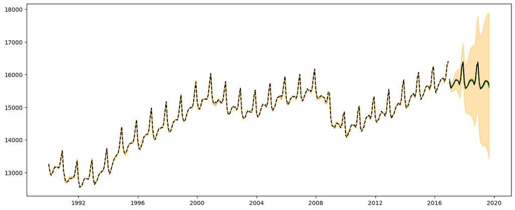

```python
fig, ax = plt.subplots( figsize=(15, 6) )

ax.plot( train_series, color='orange', label='train' )

ax.fill_between(hw_summary_df.index,
                hw_summary_df.lwr,
                hw_summary_df.upr,
                color='orange', alpha=0.33)

ax.plot( test_series, color = 'green', label ='test' )

ax.plot( train_hw_model_fit.fittedvalues, color='black', linestyle='--', label='fits' )

ax.plot( hw_forecast, color='black', label='forecast' )

plt.show()
```

### SES and STL

Last week, we manually combined a simple forecasting approach with the STL decomposition. This provides for a very flexible modle, but the manual execution was quite tedious. In practice, you do not need to manually create such a model. Instead, a function call exists to combine a simple forecaster like SES with the STL method.

```python
from statsmodels.tsa.forecasting.stl import STLForecast
```

```python
train_stlf_model_fit = STLForecast( train_series, SimpleExpSmoothing,
                                   model_kwargs={'initialization_method': 'estimated'}).fit()
```

```python
print( train_stlf_model_fit.summary() )
```

```
            STL Decomposition and SimpleExpSmoothing Model Results
==============================================================================
Dep. Variable:                   None   No. Observations:                  324
Model:             SimpleExpSmoothing   SSE                         337554.416
Optimized:                       True   AIC                           2255.391
Trend:                           None   BIC                           2262.953
Seasonal:                        None   AICC                          2255.517
Seasonal Periods:                None   Date:                 Tue, 14 Mar 2023
Box-Cox:                        False   Time:                         20:30:33
Box-Cox Coeff.:                  None
==============================================================================
                       coeff                 code              optimized
------------------------------------------------------------------------------
smoothing_level            0.9950000                alpha                 True
initial_level              13293.381                  l.0                 True
                                STL Configuration
=================================================================================
Period:                            12       Trend Length:                      23
Seasonal:                           7       Trend deg:                          1
Seasonal deg:                       1       Trend jump:                         1
Seasonal jump:                      1       Low pass:                          13
Robust:                         False       Low pass deg:                       1
---------------------------------------------------------------------------------
```

```python
stlf_forecast = train_stlf_model_fit.forecast( test_series.size )
```

```python
stlf_forecast
```

```
2017-01-01    15809.081633
2017-02-01    15633.448910
2017-03-01    15696.881883
2017-04-01    15759.363254
2017-05-01    15848.998665
2017-06-01    15938.529695
2017-07-01    15947.444876
2017-08-01    15911.223332
2017-09-01    15778.289978
2017-10-01    15928.803513
2017-11-01    16277.647361
2017-12-01    16394.212027
2018-01-01    15809.081633
2018-02-01    15633.448910
2018-03-01    15696.881883
2018-04-01    15759.363254
2018-05-01    15848.998665
2018-06-01    15938.529695
2018-07-01    15947.444876
2018-08-01    15911.223332
2018-09-01    15778.289978
2018-10-01    15928.803513
2018-11-01    16277.647361
2018-12-01    16394.212027
2019-01-01    15809.081633
2019-02-01    15633.448910
2019-03-01    15696.881883
2019-04-01    15759.363254
2019-05-01    15848.998665
2019-06-01    15938.529695
2019-07-01    15947.444876
2019-08-01    15911.223332
2019-09-01    15778.289978
Freq: MS, dtype: float64
```

Accessing information associated with the **composite** model is trickier though. This is because there are technically two different operations taking place. The model fits can be found within the `.model_result` attribute.

```python
train_stlf_model_fit.model_result.fittedvalues
```

```
date_dt
1990-01-01    13293.380835
1990-02-01    13259.669390
1990-03-01    13254.723180
1990-04-01    13244.906953
1990-05-01    13248.059388
                  ...
2016-08-01    15840.025168
2016-09-01    15866.383100
2016-10-01    15885.055076
2016-11-01    15883.841469
2016-12-01    15895.632272
Freq: MS, Length: 324, dtype: float64
```

As you can see below, the `.model_result.fittedvalues` correspond to the seasonally adjusted fits.

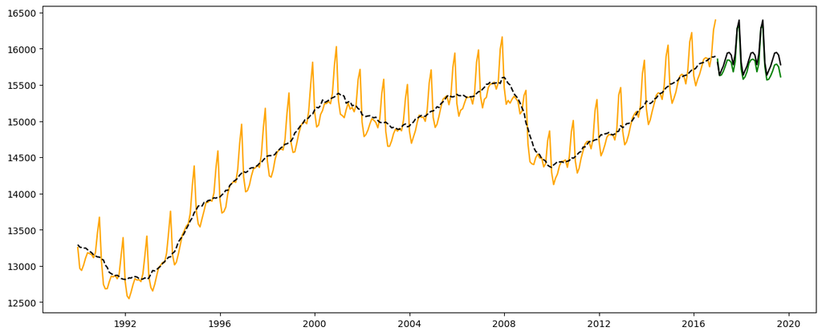

```python
fig, ax = plt.subplots( figsize=(15, 6) )

ax.plot( train_series, color='orange' )

ax.plot( test_series, color='green' )

ax.plot( train_stlf_model_fit.model_result.fittedvalues, color='black', linestyle='--', label='fits' )

ax.plot( stlf_forecast, color='black' )

plt.show()
```

I recommend comparing the composite model with other approaches with hold out TEST SETS compared with AIC/BIC/AICc due to the fact this method involves two modeling "levels". The hold out TEST SET RMSE for this composite model is given below. The composite model model does not perform as well as the Holt-Winters method in this case.

```python
np.sqrt( ( ( test_series - stlf_forecast )**2 ).mean() )
```

```
100.92149119553984
```

We essentially manually created this model last week. As a reminder, the manual STL Reseason Naive model had a hold out TEST SET RMSE of about 100. The `STLForecast()` function is capable of creating the model that we manually made! Thus, you do not need to manually go through the tedious actions from last week. In practice, you can use `STLForecast()` to create such a model!

## Summary

This report demonstrated how to use `statsmodels` to train SES, Exponential Smoothing models such as Holt-Winters, and composite models that combine STL with SES. Making and visualizing forecasts and forecast Prediction Intervals were demonstrated. Lastly, model selection concepts of identifying the best model based on hold-out TEST SETS and Information Criterion metrics including AIC, BIC, and AICc were discussed.